# Project-phase1

## Names:

- **Ahmed Ayman Abd-Alaziz Sharf** *1806171*
- **Ahmed Khaled Mohamed Esmail ElGazzar** *1805106*
- Data Desciption.
- Data split.
- Data Tuning.
- Classifiers: .
  - KNN.
  - Logistic Regression.
  - Naive Bayes.
  - Descion Tree.
  - SVM.
- Conclusion.

# Imports

```python
#default libraries for Machine learning
import numpy as np #arrays + math
import pandas as pd #pandas to read data
import matplotlib.pyplot as plt #to plot curves
import random #can make uniform and normal/gaussian disbrutions
import pickle # if data is in okl format not csv

import statsmodels.api as sm
# We can override the default matplotlib styles with those of Seaborn
import seaborn as sns
sns.set()

#select most relevent features
from sklearn.feature_selection import SelectKBest
from sklearn.feature_selection import chi2

#scipy for constants c = 3 * 10^8 and so on
import scipy
from scipy.constants import *
import scipy.stats
from scipy.stats import norm

from sklearn.preprocessing import StandardScaler #if it's normal distrubtued Tune input range to be -1 -> 1
from sklearn.preprocessing import MinMaxScaler,normalize  #Tune input range to be 0 -> 1
from sklearn.model_selection import KFold
from sklearn.metrics import precision_recall_fscore_support

#Classifer
from sklearn.neighbors import KNeighborsClassifier #KNN
from sklearn.naive_bayes import GaussianNB #naive bayes
from sklearn.svm import SVC #SVM
from sklearn.tree import DecisionTreeClassifier #DT
from sklearn import linear_model #have logestic regression

#Tune Hyperparameters
from sklearn.model_selection import GridSearchCV #to get all hyperparams
from sklearn.model_selection import cross_val_predict #to get scores
from sklearn.model_selection import cross_val_score #to get scores

#All Metrics for performance of classifier
from sklearn.metrics import confusion_matrix
from sklearn.metrics import recall_score
from sklearn.metrics import precision_score
from sklearn.metrics import f1_score
from sklearn.metrics import classification_report #summary of all above
from sklearn.metrics import precision_recall_curve #trade of between precision and recall

#to print the curve TPR vs FPR
from sklearn.metrics import roc_curve #to get tpr, fpr
from sklearn.metrics import roc_auc_score, auc # to get auc_value
from sklearn.metrics import plot_roc_curve



#Classifer
from sklearn import datasets, preprocessing # to get free data sets and linear model and preprocessing
from sklearn.linear_model import LinearRegression #linear regresion model
from sklearn.preprocessing import PolynomialFeatures #to transform feature to X^1, X^2, ...
from sklearn.model_selection import train_test_split #split data frame to train 80% and test 20%
from sklearn.metrics import mean_squared_error #measure performance of Linear Regression
from sklearn import datasets, linear_model, preprocessing
import matplotlib.colors as colors
import itertools




from numpy.linalg import inv
from numpy.linalg import det
from sympy import *
from sympy.plotting.plot import List2DSeries
from scipy.optimize import minimize
from scipy.stats import multivariate_normal
import sys
```

# 1-Descripe_DataFrame

```python
df = pd.read_csv('data.csv', index_col=0)
df
```

|  | location | country | gender | age | vis_wuhan | from_wuhan | symptom1 | symptom2 | symptom3 | symptom4 | symptom5 | symptom6 | diff_sym_hos | result |
| --- | --- | --- | --- | --- | --- | --- | --- | --- | --- | --- | --- | --- | --- | --- |
| 0 | 104 | 8 | 1 | 66.0 | 1 | 0 | 14 | 31 | 19 | 12 | 3 | 1 | 8 | 1 |
| 1 | 101 | 8 | 0 | 56.0 | 0 | 1 | 14 | 31 | 19 | 12 | 3 | 1 | 0 | 0 |
| 2 | 137 | 8 | 1 | 46.0 | 0 | 1 | 14 | 31 | 19 | 12 | 3 | 1 | 13 | 0 |
| 3 | 116 | 8 | 0 | 60.0 | 1 | 0 | 14 | 31 | 19 | 12 | 3 | 1 | 0 | 0 |
| 4 | 116 | 8 | 1 | 58.0 | 0 | 0 | 14 | 31 | 19 | 12 | 3 | 1 | 0 | 0 |
| ... | ... | ... | ... | ... | ... | ... | ... | ... | ... | ... | ... | ... | ... | ... |
| 858 | 48 | 3 | 2 | 24.0 | 0 | 0 | 14 | 31 | 19 | 12 | 3 | 1 | 0 | 1 |
| 859 | 0 | 0 | 2 | 35.0 | 0 | 0 | 14 | 31 | 19 | 12 | 3 | 1 | 0 | 0 |
| 860 | 3 | 1 | 1 | 49.4 | 0 | 0 | 14 | 31 | 19 | 12 | 3 | 1 | 0 | 0 |
| 861 | 24 | 9 | 1 | 49.4 | 0 | 0 | 14 | 31 | 19 | 12 | 3 | 1 | 0 | 0 |
| 862 | 15 | 27 | 1 | 70.0 | 0 | 0 | 14 | 31 | 19 | 12 | 3 | 1 | 0 | 0 |

863 rows × 14 columns

```python
df.isna().sum() #it seems data frame doesnt have NaN values lets check again by removeing rows with NaN
```

```
location        0
country         0
gender          0
age             0
vis_wuhan       0
from_wuhan      0
symptom1        0
symptom2        0
symptom3        0
symptom4        0
symptom5        0
symptom6        0
diff_sym_hos    0
result          0
dtype: int64
```

```python
df.dropna()
df #its clean and pre processed data set
```

|  | location | country | gender | age | vis_wuhan | from_wuhan | symptom1 | symptom2 | symptom3 | symptom4 | symptom5 | symptom6 | diff_sym_hos | result |
| --- | --- | --- | --- | --- | --- | --- | --- | --- | --- | --- | --- | --- | --- | --- |
| 0 | 104 | 8 | 1 | 66.0 | 1 | 0 | 14 | 31 | 19 | 12 | 3 | 1 | 8 | 1 |
| 1 | 101 | 8 | 0 | 56.0 | 0 | 1 | 14 | 31 | 19 | 12 | 3 | 1 | 0 | 0 |
| 2 | 137 | 8 | 1 | 46.0 | 0 | 1 | 14 | 31 | 19 | 12 | 3 | 1 | 13 | 0 |
| 3 | 116 | 8 | 0 | 60.0 | 1 | 0 | 14 | 31 | 19 | 12 | 3 | 1 | 0 | 0 |
| 4 | 116 | 8 | 1 | 58.0 | 0 | 0 | 14 | 31 | 19 | 12 | 3 | 1 | 0 | 0 |
| ... | ... | ... | ... | ... | ... | ... | ... | ... | ... | ... | ... | ... | ... | ... |
| 858 | 48 | 3 | 2 | 24.0 | 0 | 0 | 14 | 31 | 19 | 12 | 3 | 1 | 0 | 1 |
| 859 | 0 | 0 | 2 | 35.0 | 0 | 0 | 14 | 31 | 19 | 12 | 3 | 1 | 0 | 0 |
| 860 | 3 | 1 | 1 | 49.4 | 0 | 0 | 14 | 31 | 19 | 12 | 3 | 1 | 0 | 0 |
| 861 | 24 | 9 | 1 | 49.4 | 0 | 0 | 14 | 31 | 19 | 12 | 3 | 1 | 0 | 0 |
| 862 | 15 | 27 | 1 | 70.0 | 0 | 0 | 14 | 31 | 19 | 12 | 3 | 1 | 0 | 0 |

863 rows × 14 columns

```python
df.describe() #to know some details about this data frame
```

|  | location | country | gender | age | vis_wuhan | from_wuhan | symptom1 | symptom2 | symptom3 | symptom4 | symptom5 | symptom6 | diff_sym_hos | result |
| --- | --- | --- | --- | --- | --- | --- | --- | --- | --- | --- | --- | --- | --- | --- |
| count | 863.000000 | 863.000000 | 863.000000 | 863.000000 | 863.000000 | 863.000000 | 863.00000 | 863.000000 | 863.000000 | 863.000000 | 863.000000 | 863.000000 | 863.000000 | 863.000000 |
| mean | 76.645423 | 16.995365 | 0.849363 | 49.400000 | 0.181924 | 0.107764 | 12.13905 | 28.002317 | 18.298957 | 11.840093 | 2.993048 | 0.998841 | 0.995365 | 0.125145 |
| std | 39.200264 | 7.809951 | 0.726062 | 15.079203 | 0.386005 | 0.310261 | 3.99787 | 7.473231 | 2.864064 | 1.183771 | 0.127251 | 0.034040 | 2.358767 | 0.331075 |
| min | 0.000000 | 0.000000 | 0.000000 | 2.000000 | 0.000000 | 0.000000 | 0.00000 | 0.000000 | 0.000000 | 0.000000 | 0.000000 | 0.000000 | -5.000000 | 0.000000 |
| 25% | 45.000000 | 11.000000 | 0.000000 | 40.000000 | 0.000000 | 0.000000 | 14.00000 | 31.000000 | 19.000000 | 12.000000 | 3.000000 | 1.000000 | 0.000000 | 0.000000 |
| 50% | 87.000000 | 18.000000 | 1.000000 | 49.400000 | 0.000000 | 0.000000 | 14.00000 | 31.000000 | 19.000000 | 12.000000 | 3.000000 | 1.000000 | 0.000000 | 0.000000 |
| 75% | 110.000000 | 24.000000 | 1.000000 | 57.000000 | 0.000000 | 0.000000 | 14.00000 | 31.000000 | 19.000000 | 12.000000 | 3.000000 | 1.000000 | 1.000000 | 0.000000 |
| max | 138.000000 | 33.000000 | 2.000000 | 96.000000 | 1.000000 | 1.000000 | 24.00000 | 31.000000 | 19.000000 | 12.000000 | 3.000000 | 1.000000 | 15.000000 | 1.000000 |

# Removing Outlier

```python
def Zscore_outlier(df, colmn):
    out = []
    m = np.mean(df)
    sd = np.std(df)
    for i in df:
        z = (i-m)/sd
        if np.abs(z) > 3 :
            out.append(i)
    print("Outliers at {}: ".format(colmn),out)
    return out
```

```python
df.columns
```

```
Index(['location', 'country', 'gender', 'age', 'vis_wuhan', 'from_wuhan',
       'symptom1', 'symptom2', 'symptom3', 'symptom4', 'symptom5', 'symptom6',
       'diff_sym_hos', 'result'],
      dtype='object')
```

```python
for colmn in df.columns:
    outlier = Zscore_outlier(df[colmn], colmn)
    for e in outlier:
        i = df[df[colmn] == e].index
        df = df.drop(index = i)
df
```

```
Outliers at location:  []
Outliers at country:  []
Outliers at gender:  []
Outliers at age:  [2.0, 4.0, 96.0]
Outliers at vis_wuhan:  []
Outliers at from_wuhan:  []
Outliers at symptom1:  [0]
Outliers at symptom2:  [5, 0, 2, 5, 5, 5, 1, 4, 3, 5, 5, 5, 5]
Outliers at symptom3:  [5, 8, 3, 7, 4, 3, 6, 5, 2, 5, 8, 6, 8, 5, 6, 8, 2, 8, 8, 0, 8, 6, 8, 6, 7, 5, 8, 7, 6, 2, 6, 9, 3, 1]
Outliers at symptom4:  [7, 2, 2, 9]
Outliers at symptom5:  []
Outliers at symptom6:  []
Outliers at diff_sym_hos:  [8, 13, 8, 12, 15, 8, 9, 10, 12, 14, 9, 8, 9, 15, 9, 9, 10, 9, 8, 11, 8, 10, 8, 12, 12, 14, 9, 12, 13, 8]
Outliers at result:  []
```

|  | location | country | gender | age | vis_wuhan | from_wuhan | symptom1 | symptom2 | symptom3 | symptom4 | symptom5 | symptom6 | diff_sym_hos | result |
| --- | --- | --- | --- | --- | --- | --- | --- | --- | --- | --- | --- | --- | --- | --- |
| 1 | 101 | 8 | 0 | 56.0 | 0 | 1 | 14 | 31 | 19 | 12 | 3 | 1 | 0 | 0 |
| 3 | 116 | 8 | 0 | 60.0 | 1 | 0 | 14 | 31 | 19 | 12 | 3 | 1 | 0 | 0 |
| 4 | 116 | 8 | 1 | 58.0 | 0 | 0 | 14 | 31 | 19 | 12 | 3 | 1 | 0 | 0 |
| 5 | 23 | 8 | 0 | 44.0 | 0 | 1 | 14 | 31 | 19 | 12 | 3 | 1 | 0 | 0 |
| 6 | 105 | 8 | 1 | 34.0 | 0 | 1 | 14 | 31 | 19 | 12 | 3 | 1 | 0 | 0 |
| ... | ... | ... | ... | ... | ... | ... | ... | ... | ... | ... | ... | ... | ... | ... |
| 858 | 48 | 3 | 2 | 24.0 | 0 | 0 | 14 | 31 | 19 | 12 | 3 | 1 | 0 | 1 |
| 859 | 0 | 0 | 2 | 35.0 | 0 | 0 | 14 | 31 | 19 | 12 | 3 | 1 | 0 | 0 |
| 860 | 3 | 1 | 1 | 49.4 | 0 | 0 | 14 | 31 | 19 | 12 | 3 | 1 | 0 | 0 |
| 861 | 24 | 9 | 1 | 49.4 | 0 | 0 | 14 | 31 | 19 | 12 | 3 | 1 | 0 | 0 |
| 862 | 15 | 27 | 1 | 70.0 | 0 | 0 | 14 | 31 | 19 | 12 | 3 | 1 | 0 | 0 |

778 rows × 14 columns

```python
(883 - 778) / 883
```

```
0.11891279728199321
```

```python
df = pd.read_csv('data.csv', index_col=0)
df
```

|  | location | country | gender | age | vis_wuhan | from_wuhan | symptom1 | symptom2 | symptom3 | symptom4 | symptom5 | symptom6 | diff_sym_hos | result |
| --- | --- | --- | --- | --- | --- | --- | --- | --- | --- | --- | --- | --- | --- | --- |
| 0 | 104 | 8 | 1 | 66.0 | 1 | 0 | 14 | 31 | 19 | 12 | 3 | 1 | 8 | 1 |
| 1 | 101 | 8 | 0 | 56.0 | 0 | 1 | 14 | 31 | 19 | 12 | 3 | 1 | 0 | 0 |
| 2 | 137 | 8 | 1 | 46.0 | 0 | 1 | 14 | 31 | 19 | 12 | 3 | 1 | 13 | 0 |
| 3 | 116 | 8 | 0 | 60.0 | 1 | 0 | 14 | 31 | 19 | 12 | 3 | 1 | 0 | 0 |
| 4 | 116 | 8 | 1 | 58.0 | 0 | 0 | 14 | 31 | 19 | 12 | 3 | 1 | 0 | 0 |
| ... | ... | ... | ... | ... | ... | ... | ... | ... | ... | ... | ... | ... | ... | ... |
| 858 | 48 | 3 | 2 | 24.0 | 0 | 0 | 14 | 31 | 19 | 12 | 3 | 1 | 0 | 1 |
| 859 | 0 | 0 | 2 | 35.0 | 0 | 0 | 14 | 31 | 19 | 12 | 3 | 1 | 0 | 0 |
| 860 | 3 | 1 | 1 | 49.4 | 0 | 0 | 14 | 31 | 19 | 12 | 3 | 1 | 0 | 0 |
| 861 | 24 | 9 | 1 | 49.4 | 0 | 0 | 14 | 31 | 19 | 12 | 3 | 1 | 0 | 0 |
| 862 | 15 | 27 | 1 | 70.0 | 0 | 0 | 14 | 31 | 19 | 12 | 3 | 1 | 0 | 0 |

863 rows × 14 columns

# The Most Affecting Features

```python
from sklearn.feature_selection import SelectKBest
from sklearn.feature_selection import chi2
x1 = df.drop(['result'],axis =1)
x1 = x1 * (x1 > 0)
y1 = df['result']
bestfeatures = SelectKBest(score_func=chi2, k=10)
fit = bestfeatures.fit(x1,y1)
dfscores = pd.DataFrame(fit.scores_)
dfcolumns = pd.DataFrame(x1.columns)
featureScores = pd.concat([dfcolumns,dfscores],axis=1)
featureScores.columns = ['Specs','Score']
print(featureScores.nlargest(13,'Score'))
```

```
           Specs        Score
3            age  1052.849185
12  diff_sym_hos   227.399383
0       location    36.951263
6       symptom1    30.169106
1        country    27.593793
7       symptom2    18.334923
4      vis_wuhan    16.123593
5     from_wuhan    12.677731
8       symptom3     2.172480
2         gender     2.019685
9       symptom4     1.205944
10      symptom5     0.001994
11      symptom6     0.000166
```

But i Wont remove symptom6 and symptom5 as data is preprocessed and clean

```python
#Okay We are ready now with clean data frame lets get train and test
# first get features and get labels in feat, labels

feat = df.iloc[:, 0:13] #features
labels = df.iloc[:, 13] #labels
```

```python
feat
```

|  | location | country | gender | age | vis_wuhan | from_wuhan | symptom1 | symptom2 | symptom3 | symptom4 | symptom5 | symptom6 | diff_sym_hos |
| --- | --- | --- | --- | --- | --- | --- | --- | --- | --- | --- | --- | --- | --- |
| 0 | 104 | 8 | 1 | 66.0 | 1 | 0 | 14 | 31 | 19 | 12 | 3 | 1 | 8 |
| 1 | 101 | 8 | 0 | 56.0 | 0 | 1 | 14 | 31 | 19 | 12 | 3 | 1 | 0 |
| 2 | 137 | 8 | 1 | 46.0 | 0 | 1 | 14 | 31 | 19 | 12 | 3 | 1 | 13 |
| 3 | 116 | 8 | 0 | 60.0 | 1 | 0 | 14 | 31 | 19 | 12 | 3 | 1 | 0 |
| 4 | 116 | 8 | 1 | 58.0 | 0 | 0 | 14 | 31 | 19 | 12 | 3 | 1 | 0 |
| ... | ... | ... | ... | ... | ... | ... | ... | ... | ... | ... | ... | ... | ... |
| 858 | 48 | 3 | 2 | 24.0 | 0 | 0 | 14 | 31 | 19 | 12 | 3 | 1 | 0 |
| 859 | 0 | 0 | 2 | 35.0 | 0 | 0 | 14 | 31 | 19 | 12 | 3 | 1 | 0 |
| 860 | 3 | 1 | 1 | 49.4 | 0 | 0 | 14 | 31 | 19 | 12 | 3 | 1 | 0 |
| 861 | 24 | 9 | 1 | 49.4 | 0 | 0 | 14 | 31 | 19 | 12 | 3 | 1 | 0 |
| 862 | 15 | 27 | 1 | 70.0 | 0 | 0 | 14 | 31 | 19 | 12 | 3 | 1 | 0 |

863 rows × 13 columns

```python
labels
```

```
0      1
1      0
2      0
3      0
4      0
      ..
858    1
859    0
860    0
861    0
862    0
Name: result, Length: 863, dtype: int64
```

# 2-Split_data

```python
#split all data to 80% Train and 20% Test
Xtrain, Xtest, Ytrain, Ytest = train_test_split(feat, labels, random_state=42, train_size= 0.8, test_size=0.2)#return splited data in form of arr
#return splited data in form of data_frame
print(len(Xtrain))
print(len(Ytrain))
print(len(Xtest))
print(len(Ytest))
```

```
690
690
173
173
```

```python
Xtrain #in form of data_frame
```

|  | location | country | gender | age | vis_wuhan | from_wuhan | symptom1 | symptom2 | symptom3 | symptom4 | symptom5 | symptom6 | diff_sym_hos |
| --- | --- | --- | --- | --- | --- | --- | --- | --- | --- | --- | --- | --- | --- |
| 192 | 1 | 18 | 1 | 45.0 | 0 | 1 | 14 | 31 | 19 | 12 | 3 | 1 | 1 |
| 155 | 17 | 11 | 1 | 48.0 | 1 | 0 | 14 | 31 | 19 | 12 | 3 | 1 | 0 |
| 319 | 78 | 18 | 0 | 45.0 | 0 | 0 | 6 | 24 | 19 | 12 | 3 | 1 | 0 |
| 101 | 135 | 8 | 1 | 24.0 | 1 | 0 | 14 | 31 | 19 | 12 | 3 | 1 | 0 |
| 368 | 106 | 23 | 1 | 64.0 | 0 | 0 | 14 | 31 | 19 | 12 | 3 | 1 | 1 |
| ... | ... | ... | ... | ... | ... | ... | ... | ... | ... | ... | ... | ... | ... |
| 106 | 13 | 8 | 1 | 49.4 | 1 | 0 | 14 | 31 | 19 | 12 | 3 | 1 | 4 |
| 270 | 51 | 18 | 0 | 55.0 | 0 | 0 | 4 | 15 | 5 | 12 | 3 | 1 | 3 |
| 860 | 3 | 1 | 1 | 49.4 | 0 | 0 | 14 | 31 | 19 | 12 | 3 | 1 | 0 |
| 435 | 108 | 24 | 0 | 34.0 | 0 | 0 | 14 | 31 | 19 | 12 | 3 | 1 | 0 |
| 102 | 135 | 8 | 0 | 32.0 | 0 | 1 | 14 | 31 | 19 | 12 | 3 | 1 | 0 |

690 rows × 13 columns

```python
Xtest
```

|  | location | country | gender | age | vis_wuhan | from_wuhan | symptom1 | symptom2 | symptom3 | symptom4 | symptom5 | symptom6 | diff_sym_hos |
| --- | --- | --- | --- | --- | --- | --- | --- | --- | --- | --- | --- | --- | --- |
| 715 | 45 | 13 | 1 | 51.0 | 0 | 0 | 6 | 31 | 19 | 12 | 3 | 1 | 7 |
| 605 | 12 | 12 | 1 | 33.0 | 0 | 0 | 14 | 31 | 19 | 12 | 3 | 1 | 0 |
| 120 | 99 | 8 | 0 | 70.0 | 0 | 1 | 14 | 31 | 19 | 12 | 3 | 1 | 0 |
| 208 | 22 | 18 | 1 | 45.0 | 0 | 1 | 14 | 31 | 19 | 12 | 3 | 1 | 3 |
| 380 | 106 | 23 | 0 | 79.0 | 0 | 0 | 14 | 31 | 19 | 12 | 3 | 1 | 15 |
| ... | ... | ... | ... | ... | ... | ... | ... | ... | ... | ... | ... | ... | ... |
| 235 | 128 | 18 | 0 | 85.0 | 0 | 0 | 14 | 31 | 19 | 12 | 3 | 1 | 0 |
| 333 | 117 | 18 | 1 | 75.0 | 0 | 0 | 6 | 7 | 16 | 12 | 3 | 1 | 0 |
| 215 | 117 | 18 | 1 | 75.0 | 0 | 0 | 6 | 31 | 19 | 12 | 3 | 1 | 0 |
| 796 | 21 | 25 | 1 | 30.0 | 0 | 0 | 14 | 31 | 19 | 12 | 3 | 1 | 0 |
| 7 | 13 | 8 | 1 | 37.0 | 1 | 0 | 14 | 31 | 19 | 12 | 3 | 1 | 6 |

173 rows × 13 columns

# 3-Tune_Input_Ranges

```python
scaler = MinMaxScaler(feature_range=(0, 1))
knn_train_corona = pd.DataFrame(scaler.fit_transform(Xtrain), columns=Xtrain.columns, index=Xtrain.index)
knn_train_corona
```

|  | location | country | gender | age | vis_wuhan | from_wuhan | symptom1 | symptom2 | symptom3 | symptom4 | symptom5 | symptom6 | diff_sym_hos |
| --- | --- | --- | --- | --- | --- | --- | --- | --- | --- | --- | --- | --- | --- |
| 192 | 0.007246 | 0.545455 | 0.5 | 0.445652 | 0.0 | 1.0 | 0.583333 | 1.000000 | 1.000000 | 1.0 | 1.0 | 0.0 | 0.315789 |
| 155 | 0.123188 | 0.333333 | 0.5 | 0.478261 | 1.0 | 0.0 | 0.583333 | 1.000000 | 1.000000 | 1.0 | 1.0 | 0.0 | 0.263158 |
| 319 | 0.565217 | 0.545455 | 0.0 | 0.445652 | 0.0 | 0.0 | 0.250000 | 0.774194 | 1.000000 | 1.0 | 1.0 | 0.0 | 0.263158 |
| 101 | 0.978261 | 0.242424 | 0.5 | 0.217391 | 1.0 | 0.0 | 0.583333 | 1.000000 | 1.000000 | 1.0 | 1.0 | 0.0 | 0.263158 |
| 368 | 0.768116 | 0.696970 | 0.5 | 0.652174 | 0.0 | 0.0 | 0.583333 | 1.000000 | 1.000000 | 1.0 | 1.0 | 0.0 | 0.315789 |
| ... | ... | ... | ... | ... | ... | ... | ... | ... | ... | ... | ... | ... | ... |
| 106 | 0.094203 | 0.242424 | 0.5 | 0.493478 | 1.0 | 0.0 | 0.583333 | 1.000000 | 1.000000 | 1.0 | 1.0 | 0.0 | 0.473684 |
| 270 | 0.369565 | 0.545455 | 0.0 | 0.554348 | 0.0 | 0.0 | 0.166667 | 0.483871 | 0.263158 | 1.0 | 1.0 | 0.0 | 0.421053 |
| 860 | 0.021739 | 0.030303 | 0.5 | 0.493478 | 0.0 | 0.0 | 0.583333 | 1.000000 | 1.000000 | 1.0 | 1.0 | 0.0 | 0.263158 |
| 435 | 0.782609 | 0.727273 | 0.0 | 0.326087 | 0.0 | 0.0 | 0.583333 | 1.000000 | 1.000000 | 1.0 | 1.0 | 0.0 | 0.263158 |
| 102 | 0.978261 | 0.242424 | 0.0 | 0.304348 | 0.0 | 1.0 | 0.583333 | 1.000000 | 1.000000 | 1.0 | 1.0 | 0.0 | 0.263158 |

690 rows × 13 columns

```python
knn_train_corona.describe()
```

|  | location | country | gender | age | vis_wuhan | from_wuhan | symptom1 | symptom2 | symptom3 | symptom4 | symptom5 | symptom6 | diff_sym_hos |
| --- | --- | --- | --- | --- | --- | --- | --- | --- | --- | --- | --- | --- | --- |
| count | 690.000000 | 690.000000 | 690.000000 | 690.000000 | 690.000000 | 690.000000 | 690.000000 | 690.000000 | 690.000000 | 690.000000 | 690.000000 | 690.0 | 690.000000 |
| mean | 0.562161 | 0.514888 | 0.421014 | 0.494285 | 0.179710 | 0.107246 | 0.509239 | 0.909116 | 0.964683 | 0.991425 | 0.997585 | 0.0 | 0.314264 |
| std | 0.285153 | 0.238338 | 0.364310 | 0.160668 | 0.384224 | 0.309651 | 0.161500 | 0.233527 | 0.150561 | 0.078776 | 0.045723 | 0.0 | 0.117866 |
| min | 0.000000 | 0.000000 | 0.000000 | 0.000000 | 0.000000 | 0.000000 | 0.000000 | 0.000000 | 0.000000 | 0.000000 | 0.000000 | 0.0 | 0.000000 |
| 25% | 0.326087 | 0.333333 | 0.000000 | 0.402174 | 0.000000 | 0.000000 | 0.583333 | 1.000000 | 1.000000 | 1.000000 | 1.000000 | 0.0 | 0.263158 |
| 50% | 0.655797 | 0.545455 | 0.500000 | 0.493478 | 0.000000 | 0.000000 | 0.583333 | 1.000000 | 1.000000 | 1.000000 | 1.000000 | 0.0 | 0.263158 |
| 75% | 0.797101 | 0.727273 | 0.500000 | 0.576087 | 0.000000 | 0.000000 | 0.583333 | 1.000000 | 1.000000 | 1.000000 | 1.000000 | 0.0 | 0.315789 |
| max | 1.000000 | 1.000000 | 1.000000 | 1.000000 | 1.000000 | 1.000000 | 1.000000 | 1.000000 | 1.000000 | 1.000000 | 1.000000 | 0.0 | 1.000000 |

```python
scaler = MinMaxScaler(feature_range=(0, 1))
knn_test_corona = pd.DataFrame(scaler.fit_transform(Xtest), columns=Xtest.columns, index=Xtest.index)
knn_test_corona
```

|  | location | country | gender | age | vis_wuhan | from_wuhan | symptom1 | symptom2 | symptom3 | symptom4 | symptom5 | symptom6 | diff_sym_hos |
| --- | --- | --- | --- | --- | --- | --- | --- | --- | --- | --- | --- | --- | --- |
| 715 | 0.328358 | 0.354839 | 0.5 | 0.583333 | 0.0 | 0.0 | 0.217391 | 1.000000 | 1.0000 | 1.0 | 1.0 | 1.0 | 0.466667 |
| 605 | 0.082090 | 0.322581 | 0.5 | 0.369048 | 0.0 | 0.0 | 0.565217 | 1.000000 | 1.0000 | 1.0 | 1.0 | 1.0 | 0.000000 |
| 120 | 0.731343 | 0.193548 | 0.0 | 0.809524 | 0.0 | 1.0 | 0.565217 | 1.000000 | 1.0000 | 1.0 | 1.0 | 1.0 | 0.000000 |
| 208 | 0.156716 | 0.516129 | 0.5 | 0.511905 | 0.0 | 1.0 | 0.565217 | 1.000000 | 1.0000 | 1.0 | 1.0 | 1.0 | 0.200000 |
| 380 | 0.783582 | 0.677419 | 0.0 | 0.916667 | 0.0 | 0.0 | 0.565217 | 1.000000 | 1.0000 | 1.0 | 1.0 | 1.0 | 1.000000 |
| ... | ... | ... | ... | ... | ... | ... | ... | ... | ... | ... | ... | ... | ... |
| 235 | 0.947761 | 0.516129 | 0.0 | 0.988095 | 0.0 | 0.0 | 0.565217 | 1.000000 | 1.0000 | 1.0 | 1.0 | 1.0 | 0.000000 |
| 333 | 0.865672 | 0.516129 | 0.5 | 0.869048 | 0.0 | 0.0 | 0.217391 | 0.172414 | 0.8125 | 1.0 | 1.0 | 1.0 | 0.000000 |
| 215 | 0.865672 | 0.516129 | 0.5 | 0.869048 | 0.0 | 0.0 | 0.217391 | 1.000000 | 1.0000 | 1.0 | 1.0 | 1.0 | 0.000000 |
| 796 | 0.149254 | 0.741935 | 0.5 | 0.333333 | 0.0 | 0.0 | 0.565217 | 1.000000 | 1.0000 | 1.0 | 1.0 | 1.0 | 0.000000 |
| 7 | 0.089552 | 0.193548 | 0.5 | 0.416667 | 1.0 | 0.0 | 0.565217 | 1.000000 | 1.0000 | 1.0 | 1.0 | 1.0 | 0.400000 |

173 rows × 13 columns

```python
knn_test_corona.describe()
```

|  | location | country | gender | age | vis_wuhan | from_wuhan | symptom1 | symptom2 | symptom3 | symptom4 | symptom5 | symptom6 | diff_sym_hos |
| --- | --- | --- | --- | --- | --- | --- | --- | --- | --- | --- | --- | --- | --- |
| count | 173.000000 | 173.000000 | 173.000000 | 173.000000 | 173.000000 | 173.000000 | 173.000000 | 173.000000 | 173.000000 | 173.000000 | 173.000000 | 173.000000 | 173.000000 |
| mean | 0.536753 | 0.484244 | 0.439306 | 0.560762 | 0.190751 | 0.109827 | 0.469967 | 0.871836 | 0.948699 | 0.967726 | 0.994220 | 0.994220 | 0.072832 |
| std | 0.287163 | 0.245423 | 0.358556 | 0.193507 | 0.394034 | 0.313581 | 0.193384 | 0.287076 | 0.180177 | 0.153166 | 0.076029 | 0.076029 | 0.185976 |
| min | 0.000000 | 0.000000 | 0.000000 | 0.000000 | 0.000000 | 0.000000 | 0.000000 | 0.000000 | 0.000000 | 0.000000 | 0.000000 | 0.000000 | 0.000000 |
| 25% | 0.320896 | 0.322581 | 0.000000 | 0.440476 | 0.000000 | 0.000000 | 0.217391 | 1.000000 | 1.000000 | 1.000000 | 1.000000 | 1.000000 | 0.000000 |
| 50% | 0.574627 | 0.516129 | 0.500000 | 0.564286 | 0.000000 | 0.000000 | 0.565217 | 1.000000 | 1.000000 | 1.000000 | 1.000000 | 1.000000 | 0.000000 |
| 75% | 0.813433 | 0.677419 | 0.500000 | 0.666667 | 0.000000 | 0.000000 | 0.565217 | 1.000000 | 1.000000 | 1.000000 | 1.000000 | 1.000000 | 0.066667 |
| max | 1.000000 | 1.000000 | 1.000000 | 1.000000 | 1.000000 | 1.000000 | 1.000000 | 1.000000 | 1.000000 | 1.000000 | 1.000000 | 1.000000 | 1.000000 |

# Classifiers:

## 1-KNN

### A) Largest K

- Length of n samples (data_set) is 690
- where k should be < sqrt(690) so we iterate to find best k with best CV

```python
data_length = len(Ytrain)
import math
largrest_k = math.sqrt(data_length)
largrest_k
```

```
26.267851073127396
```

```python
def make_K_odd(k):
    if int(k) % 2 == 0: #even
        return (int(k) - 1)
    else:
        return int(k)
```

```python
# K < sqrt(n)
largrest_k = make_K_odd(largrest_k)
largrest_k
```

```
25
```

Largest K is 25

### B) iterate with diff combinations of CV and K to reach largest Recall

### Method 1 by For loop

```python
#to chose K that make largest recall
largest = 0
k = 0
index = 0
df = pd.DataFrame(columns = ["k","recall"])
for i in range (1,largrest_k + 1, 2):
    knn_classifer = KNeighborsClassifier(n_neighbors = i, p=2, metric='euclidean') #p = 2 if he death or not)
    y_train_predict = cross_val_predict(knn_classifer, knn_train_corona, Ytrain, cv=10) #(fit + predictions)
    my_call = recall_score(Ytrain, y_train_predict) # TP / (p = (TP + FN))
    #print(my_call)
    #cv_r2_scores_rf = cross_val_score(knn_classifer, knn_train_corona, Ytrain, cv=10) #(fit + score(acc))
    df.loc[index, 'k'] = i
    df.loc[index,'recall'] = my_call
    index = index + 1
    #find maximum recall
    if  my_call > largest:
        largest = my_call
        k = i
print(df)
print("biggest recall:", largest, ",at k =", k)
```

```
     k    recall
0    1  0.686747
1    3  0.518072
2    5  0.445783
3    7  0.361446
4    9   0.26506
5   11  0.216867
6   13  0.192771
7   15  0.156627
8   17  0.120482
9   19  0.096386
10  21  0.096386
11  23  0.036145
12  25  0.024096
biggest recall: 0.6867469879518072 ,at k = 1
```

### Method 2 GridSearchCV

```python
#to show paramerters of Knn
KNeighborsClassifier().get_params().keys()
```

```
dict_keys(['algorithm', 'leaf_size', 'metric', 'metric_params', 'n_jobs', 'n_neighbors', 'p', 'weights'])
```

```python
'''
we have 3 hyperparams that affect the most on knn
k = range(1, largest_k, 2)
knn weights
dist
'''

model = KNeighborsClassifier() #model it's self


range_k = list(range(1, largrest_k, 2)) #range of k values that move by odd numbers

# all possible hyperparameters
model_params = { 'n_neighbors' : range_k,
               'weights' : ['uniform','distance'],
               'metric' : ['minkowski','euclidean','manhattan']}

sub_model = GridSearchCV(model, model_params, cv = 10, scoring = 'f1', n_jobs = -1, verbose = 1)

# Fit the grid
sub_model.fit(knn_train_corona, Ytrain)

print("Best cross-validation score: {:.2f}".format(sub_model.best_score_))
print("Best parameters: \n{}".format(sub_model.best_params_))
```

```
Fitting 10 folds for each of 72 candidates, totalling 720 fits
Best cross-validation score: 0.75
Best parameters:
{'metric': 'manhattan', 'n_neighbors': 3, 'weights': 'distance'}
```

```python
sub_model.best_params_
```

```
{'metric': 'manhattan', 'n_neighbors': 3, 'weights': 'distance'}
```

```python
best_k = sub_model.best_params_['n_neighbors']
best_metric = sub_model.best_params_['metric']
best_weight = sub_model.best_params_['weights']
print(best_k)
print(best_metric)
print(best_weight)
```

```
3
manhattan
distance
```

```python
#make empty model
knn_classifer = KNeighborsClassifier(n_neighbors = best_k, p=2, metric = best_metric, weights = best_weight)#p = 2 if he death or not

#fit with xtrain ytrain
knn_classifer.fit(knn_train_corona, Ytrain)

# #predict
# y_pred = knn_classifer.predict(Xtest)
# y_pred
```

```
KNeighborsClassifier(metric='manhattan', n_neighbors=3, weights='distance')
```

### C) Performance of model on Train and Test Data

```python
#predicted_values on Ytest = knn_test_corona
# predicted_values = knn_classifer.predict(testX_)
predicted_values = knn_classifer.predict(knn_test_corona)
predicted_values
```

```
array([0, 0, 1, 0, 0, 0, 0, 0, 0, 0, 1, 0, 0, 0, 0, 0, 1, 0, 0, 0, 0, 0,
       0, 0, 0, 0, 0, 0, 0, 1, 0, 0, 0, 0, 0, 0, 0, 0, 0, 1, 0, 0, 0, 0,
       0, 0, 0, 0, 0, 0, 0, 0, 0, 0, 0, 0, 0, 0, 0, 0, 0, 0, 0, 0, 0, 0,
       0, 0, 0, 0, 0, 0, 0, 0, 0, 1, 0, 0, 0, 0, 0, 0, 0, 0, 0, 0, 0, 0,
       0, 0, 1, 0, 0, 1, 0, 0, 0, 0, 0, 0, 0, 0, 0, 0, 0, 1, 0, 0, 1, 0,
       0, 0, 1, 0, 0, 0, 0, 0, 1, 0, 0, 1, 1, 0, 0, 0, 0, 0, 0, 0, 0, 1,
       0, 1, 0, 0, 1, 0, 0, 0, 0, 0, 0, 0, 0, 0, 0, 0, 0, 0, 1, 0, 0, 0,
       0, 0, 0, 0, 0, 1, 0, 1, 0, 1, 0, 1, 1, 0, 0, 0, 1, 0, 0])
```

```python
#predicted_probablity on Ytest = knn_test_corona
preds_prob = knn_classifer.predict_proba(knn_test_corona)[:, 1]

preds_prob
# len(preds_prob)
```

```
array([0.3227009 , 0.        , 0.65286966, 0.        , 0.32914578,
       0.        , 0.30990241, 0.        , 0.        , 0.        ,
       0.67699693, 0.3112986 , 0.        , 0.        , 0.        ,
       0.        , 1.        , 0.        , 0.        , 0.32977045,
       0.        , 0.        , 0.        , 0.        , 0.        ,
       0.        , 0.        , 0.        , 0.        , 1.        ,
       0.        , 0.        , 0.32925269, 0.        , 0.        ,
       0.        , 0.        , 0.        , 0.        , 0.66350335,
       0.        , 0.        , 0.        , 0.31851212, 0.        ,
       0.        , 0.        , 0.        , 0.        , 0.        ,
       0.        , 0.31427046, 0.        , 0.        , 0.        ,
       0.        , 0.        , 0.        , 0.32785297, 0.        ,
       0.        , 0.        , 0.33065965, 0.        , 0.        ,
       0.        , 0.        , 0.        , 0.        , 0.        ,
       0.        , 0.        , 0.33344234, 0.        , 0.35613493,
       1.        , 0.        , 0.        , 0.        , 0.        ,
       0.        , 0.        , 0.        , 0.31517997, 0.        ,
       0.        , 0.        , 0.        , 0.        , 0.        ,
       1.        , 0.        , 0.        , 1.        , 0.        ,
       0.        , 0.        , 0.        , 0.        , 0.        ,
       0.        , 0.        , 0.        , 0.31881617, 0.        ,
       0.67783062, 0.3337605 , 0.        , 1.        , 0.        ,
       0.        , 0.34930234, 1.        , 0.32984476, 0.        ,
       0.        , 0.        , 0.        , 0.65162965, 0.        ,
       0.        , 1.        , 0.66909272, 0.        , 0.        ,
       0.        , 0.        , 0.        , 0.32688982, 0.33387352,
       0.        , 0.6470264 , 0.        , 0.66426366, 0.        ,
       0.        , 1.        , 0.        , 0.        , 0.3235407 ,
       0.        , 0.        , 0.        , 0.        , 0.32961089,
       0.        , 0.32667808, 0.        , 0.        , 0.        ,
       0.66923649, 0.        , 0.3056172 , 0.        , 0.        ,
       0.32302021, 0.        , 0.        , 0.        , 0.65665021,
       0.        , 0.67679008, 0.        , 1.        , 0.34821821,
       1.        , 0.64734077, 0.        , 0.32286858, 0.33392852,
       0.62837157, 0.        , 0.        ])
```

```python
#roc curve on Ytest and predections
fpr, tpr, thershold = roc_curve(Ytest, preds_prob)
print(fpr)
print(tpr)
print(thershold)
```

```
[0.         0.02027027 0.02702703 0.02702703 0.0472973  0.0472973
 0.06756757 0.06756757 0.08783784 0.08783784 0.10810811 0.10810811
 0.11486486 0.11486486 0.14864865 0.14864865 0.2027027  1.        ]
[0.   0.32 0.32 0.4  0.4  0.52 0.52 0.56 0.56 0.6  0.6  0.64 0.64 0.8
 0.8  0.84 0.84 1.  ]
[2.         1.         0.67783062 0.67679008 0.66426366 0.65286966
 0.6470264  0.62837157 0.34821821 0.33392852 0.33344234 0.33065965
 0.32984476 0.32914578 0.32302021 0.32286858 0.3056172  0.        ]
```

```python
#report that have precision-recall-f1Score on Ytest

print(classification_report(Ytest, predicted_values)) #2 possible outcomes 0 => (not dead) 1 => (dead)
#for 0 we have high recall + precision + F1-score
#but for 1 smaller recall +  precision + f1-score
```

```
              precision    recall  f1-score   support

           0       0.93      0.93      0.93       148
           1       0.58      0.56      0.57        25

    accuracy                           0.88       173
   macro avg       0.75      0.75      0.75       173
weighted avg       0.88      0.88      0.88       173
```

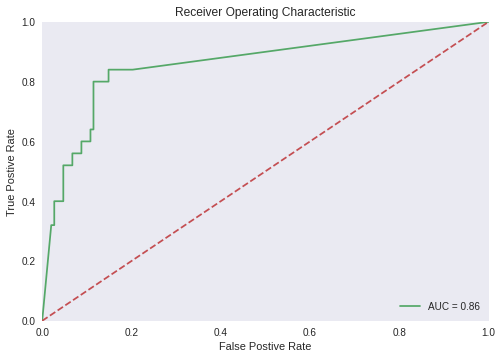

```python
#curve of TPR vs FPR on Ytest vs predictions of knn_model
plt.style.use('seaborn') #use seaborn style
#vectors are ready
auc_value = roc_auc_score(Ytest, preds_prob)
template_str = "AUC = {}".format(auc_value)
#plot
plt.plot(fpr, tpr, 'g-', label="AUC = %0.2f" % auc_value)
#properties
plt.grid()
plt.legend(loc = 'lower right')
plt.xlabel("False Postive Rate")
plt.ylabel("True Postive Rate")
plt.plot([0, 1], [0, 1], 'r--')
plt.xlim([0, 1])
plt.ylim([0, 1])
plt.title('Receiver Operating Characteristic')
plt.show()
```

```python
#auc_curve of ROC Curve
roc_auc_score(Ytest, preds_prob)
```

```
0.8578378378378377
```

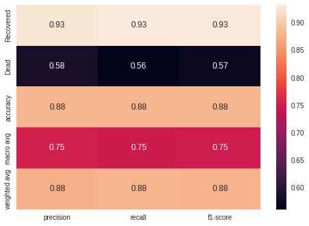

```python
#detailed report on knn_model on testing data
clf_report = classification_report(Ytest, predicted_values, target_names=['Recovered','Dead'],output_dict=True)
sns.heatmap(pd.DataFrame(clf_report).iloc[:-1, :].T, annot=True)
```

## 2-Logistic_Regression

```python
# Split into training and test
xtr = Xtrain
xts = Xtest
ytr = Ytrain
yts = Ytest

xtr = np.array(xtr)
xts = np.array(xts)
ytr = np.array(ytr)
yts = np.array(yts)
```

## A) Tuning Hyperparameters of Logistic Regression using for-loops

```python
cc = [0.01 , 0.1 , 1 , 10 , 100 , 1000 , 1e4 , 1e5 , 1e6 ]   #size = 9
solver = ['liblinear' , 'newton-cg' , 'lbfgs']               #size = 3

nfold = 10
accm = np.zeros(27)
precm = np.zeros(27)
recm = np.zeros(27)
f1m = np.zeros(27)

# Compute the standard errors
prec_se = np.zeros(27)
rec_se = np.zeros(27)
f1_se = np.zeros(27)
acc_se = np.zeros(27)

ii = 0
for c in cc:
    for sol in solver:
        kf = KFold(n_splits=nfold)
        acc = np.zeros(nfold)
        prec = np.zeros(nfold)
        rec = np.zeros(nfold)
        f1 = np.zeros(nfold)
        kf = KFold(n_splits=nfold)
        kf.get_n_splits(xtr)
        i = 0

        for all_except_index, fold_index in kf.split(xtr):

            testX = xtr[fold_index]
            testY = ytr[fold_index]
            trainX = xtr[all_except_index]
            trainY = ytr[all_except_index]
            # Scale the data
            scal = StandardScaler()
            trainX_ = scal.fit_transform(trainX)
            testX_ = scal.transform(testX)
            # Fit a model
            reg = linear_model.LogisticRegression(solver=sol , C=c)
            reg.fit(trainX_, trainY)
            # Predict on test samples and measure accuracy
            yhat = reg.predict(testX_)
            acc[i] = np.mean(yhat == testY)
            # Measure other performance metrics
            prec[i],rec[i],f1[i],_  = precision_recall_fscore_support(testY,yhat,average='binary')
            i = i + 1

        # Take average values of the metrics
        precm[ii] = np.mean(prec)
        recm[ii] = np.mean(rec)
        f1m[ii] = np.mean(f1)
        accm[ii] = np.mean(acc)

        # Compute the standard errors
        prec_se[ii] = np.std(prec)/np.sqrt(nfold-1)
        rec_se[ii] = np.std(rec)/np.sqrt(nfold-1)
        f1_se[ii] = np.std(f1)/np.sqrt(nfold-1)
        acc_se[ii] = np.std(acc)/np.sqrt(nfold-1)
        ii = ii + 1


# print(accm)
print(accm.max())
print(accm.argmax())

# print(recm)
print(recm.max())
print(recm.argmax())
```

[output not shown]

```
0.9420289855072465
12
0.6982359307359307
12
```